# INN Hotels Project

## Context

A significant number of hotel bookings are called-off due to cancellations or no-shows. The typical reasons for cancellations include change of plans, scheduling conflicts, etc. This is often made easier by the option to do so free of charge or preferably at a low cost which is beneficial to hotel guests but it is a less desirable and possibly revenue-diminishing factor for hotels to deal with. Such losses are particularly high on last-minute cancellations.

The new technologies involving online booking channels have dramatically changed customers’ booking possibilities and behavior. This adds a further dimension to the challenge of how hotels handle cancellations, which are no longer limited to traditional booking and guest characteristics.

The cancellation of bookings impact a hotel on various fronts:

- Loss of resources (revenue) when the hotel cannot resell the room.
- Additional costs of distribution channels by increasing commissions or paying for publicity to help sell these rooms.
- Lowering prices last minute, so the hotel can resell a room, resulting in reducing the profit margin.
- Human resources to make arrangements for the guests.

## Objective

The increasing number of cancellations calls for a Machine Learning based solution that can help in predicting which booking is likely to be canceled. INN Hotels Group has a chain of hotels in Portugal, they are facing problems with the high number of booking cancellations and have reached out to your firm for data-driven solutions. You as a data scientist have to analyze the data provided to find which factors have a high influence on booking cancellations, build a predictive model that can predict which booking is going to be canceled in advance, and help in formulating profitable policies for cancellations and refunds.

## Data Description

The data contains the different attributes of customers' booking details. The detailed data dictionary is given below.

**Data Dictionary**

- Booking_ID: unique identifier of each booking
- no_of_adults: Number of adults
- no_of_children: Number of Children
- no_of_weekend_nights: Number of weekend nights (Saturday or Sunday) the guest stayed or booked to stay at the hotel
- no_of_week_nights: Number of week nights (Monday to Friday) the guest stayed or booked to stay at the hotel
- type_of_meal_plan: Type of meal plan booked by the customer:
  - Not Selected – No meal plan selected
  - Meal Plan 1 – Breakfast
  - Meal Plan 2 – Half board (breakfast and one other meal)
  - Meal Plan 3 – Full board (breakfast, lunch, and dinner)
- required_car_parking_space: Does the customer require a car parking space? (0 - No, 1- Yes)
- room_type_reserved: Type of room reserved by the customer. The values are ciphered (encoded) by INN Hotels.
- lead_time: Number of days between the date of booking and the arrival date
- arrival_year: Year of arrival date
- arrival_month: Month of arrival date
- arrival_date: Date of the month
- market_segment_type: Market segment designation.
- repeated_guest: Is the customer a repeated guest? (0 - No, 1- Yes)
- no_of_previous_cancellations: Number of previous bookings that were canceled by the customer prior to the current booking
- no_of_previous_bookings_not_canceled: Number of previous bookings not canceled by the customer prior to the current booking
- avg_price_per_room: Average price per day of the reservation; prices of the rooms are dynamic. (in euros)
- no_of_special_requests: Total number of special requests made by the customer (e.g. high floor, view from the room, etc)
- booking_status: Flag indicating if the booking was canceled or not.

## Importing necessary libraries and data

```python
# Libraries to help with reading and manipulating data

import pandas as pd
import numpy as np

# Library to split data
from sklearn.model_selection import train_test_split

# libaries to help with data visualization
import matplotlib.pyplot as plt
import seaborn as sns

# Removes the limit for the number of displayed columns
pd.set_option("display.max_columns", None)
# Sets the limit for the number of displayed rows
pd.set_option("display.max_rows", 200)


# To build model for prediction
import statsmodels.stats.api as sms
from statsmodels.stats.outliers_influence import variance_inflation_factor
import statsmodels.api as sm
from statsmodels.tools.tools import add_constant
from sklearn.linear_model import LogisticRegression


# To get diferent metric scores
from sklearn.metrics import (
    f1_score,
    accuracy_score,
    recall_score,
    precision_score,
    confusion_matrix,
    roc_auc_score,
    plot_confusion_matrix,
    precision_recall_curve,
    roc_curve,
    make_scorer
)
```

## Data Overview

- Observations
- Sanity checks

```python
df = pd.read_csv("INNHotelsGroup.csv")
```

```python
# Creating a copy of dataframe to work safely w/o changes on original dataset
data = df.copy()
```

### Understand the shape of the dataset.

```python
data.head(10)
```

|  | Booking_ID | no_of_adults | no_of_children | no_of_weekend_nights | no_of_week_nights | type_of_meal_plan | required_car_parking_space | room_type_reserved | lead_time | arrival_year | arrival_month | arrival_date | market_segment_type | repeated_guest | no_of_previous_cancellations | no_of_previous_bookings_not_canceled | avg_price_per_room | no_of_special_requests | booking_status |
| --- | --- | --- | --- | --- | --- | --- | --- | --- | --- | --- | --- | --- | --- | --- | --- | --- | --- | --- | --- |
| 0 | INN00001 | 2 | 0 | 1 | 2 | Meal Plan 1 | 0 | Room_Type 1 | 224 | 2017 | 10 | 2 | Offline | 0 | 0 | 0 | 65.00 | 0 | Not_Canceled |
| 1 | INN00002 | 2 | 0 | 2 | 3 | Not Selected | 0 | Room_Type 1 | 5 | 2018 | 11 | 6 | Online | 0 | 0 | 0 | 106.68 | 1 | Not_Canceled |
| 2 | INN00003 | 1 | 0 | 2 | 1 | Meal Plan 1 | 0 | Room_Type 1 | 1 | 2018 | 2 | 28 | Online | 0 | 0 | 0 | 60.00 | 0 | Canceled |
| 3 | INN00004 | 2 | 0 | 0 | 2 | Meal Plan 1 | 0 | Room_Type 1 | 211 | 2018 | 5 | 20 | Online | 0 | 0 | 0 | 100.00 | 0 | Canceled |
| 4 | INN00005 | 2 | 0 | 1 | 1 | Not Selected | 0 | Room_Type 1 | 48 | 2018 | 4 | 11 | Online | 0 | 0 | 0 | 94.50 | 0 | Canceled |
| 5 | INN00006 | 2 | 0 | 0 | 2 | Meal Plan 2 | 0 | Room_Type 1 | 346 | 2018 | 9 | 13 | Online | 0 | 0 | 0 | 115.00 | 1 | Canceled |
| 6 | INN00007 | 2 | 0 | 1 | 3 | Meal Plan 1 | 0 | Room_Type 1 | 34 | 2017 | 10 | 15 | Online | 0 | 0 | 0 | 107.55 | 1 | Not_Canceled |
| 7 | INN00008 | 2 | 0 | 1 | 3 | Meal Plan 1 | 0 | Room_Type 4 | 83 | 2018 | 12 | 26 | Online | 0 | 0 | 0 | 105.61 | 1 | Not_Canceled |
| 8 | INN00009 | 3 | 0 | 0 | 4 | Meal Plan 1 | 0 | Room_Type 1 | 121 | 2018 | 7 | 6 | Offline | 0 | 0 | 0 | 96.90 | 1 | Not_Canceled |
| 9 | INN00010 | 2 | 0 | 0 | 5 | Meal Plan 1 | 0 | Room_Type 4 | 44 | 2018 | 10 | 18 | Online | 0 | 0 | 0 | 133.44 | 3 | Not_Canceled |

```python
data.tail(10)
```

|  | Booking_ID | no_of_adults | no_of_children | no_of_weekend_nights | no_of_week_nights | type_of_meal_plan | required_car_parking_space | room_type_reserved | lead_time | arrival_year | arrival_month | arrival_date | market_segment_type | repeated_guest | no_of_previous_cancellations | no_of_previous_bookings_not_canceled | avg_price_per_room | no_of_special_requests | booking_status |
| --- | --- | --- | --- | --- | --- | --- | --- | --- | --- | --- | --- | --- | --- | --- | --- | --- | --- | --- | --- |
| 36265 | INN36266 | 2 | 0 | 1 | 3 | Meal Plan 1 | 0 | Room_Type 1 | 15 | 2018 | 5 | 30 | Online | 0 | 0 | 0 | 100.73 | 0 | Not_Canceled |
| 36266 | INN36267 | 2 | 0 | 2 | 2 | Meal Plan 1 | 0 | Room_Type 2 | 8 | 2018 | 3 | 4 | Online | 0 | 0 | 0 | 85.96 | 1 | Canceled |
| 36267 | INN36268 | 2 | 0 | 1 | 0 | Not Selected | 0 | Room_Type 1 | 49 | 2018 | 7 | 11 | Online | 0 | 0 | 0 | 93.15 | 0 | Canceled |
| 36268 | INN36269 | 1 | 0 | 0 | 3 | Meal Plan 1 | 0 | Room_Type 1 | 166 | 2018 | 11 | 1 | Offline | 0 | 0 | 0 | 110.00 | 0 | Canceled |
| 36269 | INN36270 | 2 | 2 | 0 | 1 | Meal Plan 1 | 0 | Room_Type 6 | 0 | 2018 | 10 | 6 | Online | 0 | 0 | 0 | 216.00 | 0 | Canceled |
| 36270 | INN36271 | 3 | 0 | 2 | 6 | Meal Plan 1 | 0 | Room_Type 4 | 85 | 2018 | 8 | 3 | Online | 0 | 0 | 0 | 167.80 | 1 | Not_Canceled |
| 36271 | INN36272 | 2 | 0 | 1 | 3 | Meal Plan 1 | 0 | Room_Type 1 | 228 | 2018 | 10 | 17 | Online | 0 | 0 | 0 | 90.95 | 2 | Canceled |
| 36272 | INN36273 | 2 | 0 | 2 | 6 | Meal Plan 1 | 0 | Room_Type 1 | 148 | 2018 | 7 | 1 | Online | 0 | 0 | 0 | 98.39 | 2 | Not_Canceled |
| 36273 | INN36274 | 2 | 0 | 0 | 3 | Not Selected | 0 | Room_Type 1 | 63 | 2018 | 4 | 21 | Online | 0 | 0 | 0 | 94.50 | 0 | Canceled |
| 36274 | INN36275 | 2 | 0 | 1 | 2 | Meal Plan 1 | 0 | Room_Type 1 | 207 | 2018 | 12 | 30 | Offline | 0 | 0 | 0 | 161.67 | 0 | Not_Canceled |

```python
data.shape
```

```
(36275, 19)
```

**Jonathan's Note**: There are 36275 rows on dataset and 19 features

### Understand the shape of the dataset.

```python
data.info()
```

```
<class 'pandas.core.frame.DataFrame'>
RangeIndex: 36275 entries, 0 to 36274
Data columns (total 19 columns):
 #   Column                                Non-Null Count  Dtype
---  ------                                --------------  -----
 0   Booking_ID                            36275 non-null  object
 1   no_of_adults                          36275 non-null  int64
 2   no_of_children                        36275 non-null  int64
 3   no_of_weekend_nights                  36275 non-null  int64
 4   no_of_week_nights                     36275 non-null  int64
 5   type_of_meal_plan                     36275 non-null  object
 6   required_car_parking_space            36275 non-null  int64
 7   room_type_reserved                    36275 non-null  object
 8   lead_time                             36275 non-null  int64
 9   arrival_year                          36275 non-null  int64
 10  arrival_month                         36275 non-null  int64
 11  arrival_date                          36275 non-null  int64
 12  market_segment_type                   36275 non-null  object
 13  repeated_guest                        36275 non-null  int64
 14  no_of_previous_cancellations          36275 non-null  int64
 15  no_of_previous_bookings_not_canceled  36275 non-null  int64
 16  avg_price_per_room                    36275 non-null  float64
 17  no_of_special_requests                36275 non-null  int64
 18  booking_status                        36275 non-null  object
dtypes: float64(1), int64(13), object(5)
memory usage: 5.3+ MB
```

**Jonathan's Note**: Seems there are not missing data in dataset features, we have 5 features of object datatype that will are converted to categorical

### Checking for missing values

```python
# checking for null values
data.isnull().sum()
```

```
Booking_ID                              0
no_of_adults                            0
no_of_children                          0
no_of_weekend_nights                    0
no_of_week_nights                       0
type_of_meal_plan                       0
required_car_parking_space              0
room_type_reserved                      0
lead_time                               0
arrival_year                            0
arrival_month                           0
arrival_date                            0
market_segment_type                     0
repeated_guest                          0
no_of_previous_cancellations            0
no_of_previous_bookings_not_canceled    0
avg_price_per_room                      0
no_of_special_requests                  0
booking_status                          0
dtype: int64
```

**Jonathan's Note**: Confirmed there is not missing data

### Dropping the duplicate values

```python
# checking for duplicate values
data[data.duplicated()].count()
```

```
Booking_ID                              0
no_of_adults                            0
no_of_children                          0
no_of_weekend_nights                    0
no_of_week_nights                       0
type_of_meal_plan                       0
required_car_parking_space              0
room_type_reserved                      0
lead_time                               0
arrival_year                            0
arrival_month                           0
arrival_date                            0
market_segment_type                     0
repeated_guest                          0
no_of_previous_cancellations            0
no_of_previous_bookings_not_canceled    0
avg_price_per_room                      0
no_of_special_requests                  0
booking_status                          0
dtype: int64
```

**Jonathan's Note**: There is not duplicated data, nothing to treat

### Statistical summary of the data

**Let's check the statistical summary of the data.**

```python
data.describe().T
```

|  | count | mean | std | min | 25% | 50% | 75% | max |
| --- | --- | --- | --- | --- | --- | --- | --- | --- |
| no_of_adults | 36275.0 | 1.844962 | 0.518715 | 0.0 | 2.0 | 2.00 | 2.0 | 4.0 |
| no_of_children | 36275.0 | 0.105279 | 0.402648 | 0.0 | 0.0 | 0.00 | 0.0 | 10.0 |
| no_of_weekend_nights | 36275.0 | 0.810724 | 0.870644 | 0.0 | 0.0 | 1.00 | 2.0 | 7.0 |
| no_of_week_nights | 36275.0 | 2.204300 | 1.410905 | 0.0 | 1.0 | 2.00 | 3.0 | 17.0 |
| required_car_parking_space | 36275.0 | 0.030986 | 0.173281 | 0.0 | 0.0 | 0.00 | 0.0 | 1.0 |
| lead_time | 36275.0 | 85.232557 | 85.930817 | 0.0 | 17.0 | 57.00 | 126.0 | 443.0 |
| arrival_year | 36275.0 | 2017.820427 | 0.383836 | 2017.0 | 2018.0 | 2018.00 | 2018.0 | 2018.0 |
| arrival_month | 36275.0 | 7.423653 | 3.069894 | 1.0 | 5.0 | 8.00 | 10.0 | 12.0 |
| arrival_date | 36275.0 | 15.596995 | 8.740447 | 1.0 | 8.0 | 16.00 | 23.0 | 31.0 |
| repeated_guest | 36275.0 | 0.025637 | 0.158053 | 0.0 | 0.0 | 0.00 | 0.0 | 1.0 |
| no_of_previous_cancellations | 36275.0 | 0.023349 | 0.368331 | 0.0 | 0.0 | 0.00 | 0.0 | 13.0 |
| no_of_previous_bookings_not_canceled | 36275.0 | 0.153411 | 1.754171 | 0.0 | 0.0 | 0.00 | 0.0 | 58.0 |
| avg_price_per_room | 36275.0 | 103.423539 | 35.089424 | 0.0 | 80.3 | 99.45 | 120.0 | 540.0 |
| no_of_special_requests | 36275.0 | 0.619655 | 0.786236 | 0.0 | 0.0 | 0.00 | 1.0 | 5.0 |

**Jonathan's Notes**:

## Exploratory Data Analysis (EDA)

- EDA is an important part of any project involving data.
- It is important to investigate and understand the data better before building a model with it.
- A few questions have been mentioned below which will help you approach the analysis in the right manner and generate insights from the data.
- A thorough analysis of the data, in addition to the questions mentioned below, should be done.

**Leading Questions**:

1. What are the busiest months in the hotel?
2. Which market segment do most of the guests come from?
3. Hotel rates are dynamic and change according to demand and customer demographics. What are the differences in room prices in different market segments?
4. What percentage of bookings are canceled?
5. Repeating guests are the guests who stay in the hotel often and are important to brand equity. What percentage of repeating guests cancel?
6. Many guests have special requirements when booking a hotel room. Do these requirements affect booking cancellation?

```python
def histogram_boxplot(data, feature, figsize=(12, 7), kde=False, bins=None):
    """
    Boxplot and histogram combined

    data: dataframe
    feature: dataframe column
    figsize: size of figure (default (12,7))
    kde: whether to show the density curve (default False)
    bins: number of bins for histogram (default None)
    """
    f2, (ax_box2, ax_hist2) = plt.subplots(
        nrows=2,  # Number of rows of the subplot grid= 2
        sharex=True,  # x-axis will be shared among all subplots
        gridspec_kw={"height_ratios": (0.25, 0.75)},
        figsize=figsize,
    )  # creating the 2 subplots
    sns.boxplot(
        data=data, x=feature, ax=ax_box2, showmeans=True, color="violet"
    )  # boxplot will be created and a star will indicate the mean value of the column
    sns.histplot(
        data=data, x=feature, kde=kde, ax=ax_hist2, bins=bins, palette="winter"
    ) if bins else sns.histplot(
        data=data, x=feature, kde=kde, ax=ax_hist2
    )  # For histogram
    ax_hist2.axvline(
        data[feature].mean(), color="green", linestyle="--"
    )  # Add mean to the histogram
    ax_hist2.axvline(
        data[feature].median(), color="black", linestyle="-"
    )  # Add median to the histogram
```

```python
# function to create labeled barplots


def labeled_barplot(data, feature, perc=False, n=None):
    """
    Barplot with percentage at the top

    data: dataframe
    feature: dataframe column
    perc: whether to display percentages instead of count (default is False)
    n: displays the top n category levels (default is None, i.e., display all levels)
    """

    total = len(data[feature])  # length of the column
    count = data[feature].nunique()
    if n is None:
        plt.figure(figsize=(count + 2, 6))
    else:
        plt.figure(figsize=(n + 2, 6))

    plt.xticks(rotation=90, fontsize=15)
    ax = sns.countplot(
        data=data,
        x=feature,
        palette="Paired",
        order=data[feature].value_counts().index[:n],
    )

    for p in ax.patches:
        if perc == True:
            label = "{:.1f}%".format(
                100 * p.get_height() / total
            )  # percentage of each class of the category
        else:
            label = p.get_height()  # count of each level of the category

        x = p.get_x() + p.get_width() / 2  # width of the plot
        y = p.get_height()  # height of the plot

        ax.annotate(
            label,
            (x, y),
            ha="center",
            va="center",
            size=12,
            xytext=(0, 5),
            textcoords="offset points",
        )  # annotate the percentage

    plt.show()  # show the plot
```

```python
def stacked_barplot(data, predictor, target):
    """
    Print the category counts and plot a stacked bar chart

    data: dataframe
    predictor: independent variable
    target: target variable
    """
    count = data[predictor].nunique()
    sorter = data[target].value_counts().index[-1]
    tab1 = pd.crosstab(data[predictor], data[target], margins=True).sort_values(
        by=sorter, ascending=False
    )
    print(tab1)
    print("-" * 120)
    tab = pd.crosstab(data[predictor], data[target], normalize="index").sort_values(
        by=sorter, ascending=False
    )
    tab.plot(kind="bar", stacked=True, figsize=(count + 5, 5))
    plt.legend(
        loc="lower left", frameon=False,
    )
    plt.legend(loc="upper left", bbox_to_anchor=(1, 1))
    plt.show()
```

```python
### function to plot distributions wrt target


def distribution_plot_wrt_target(data, predictor, target):

    fig, axs = plt.subplots(2, 2, figsize=(12, 10))

    target_uniq = data[target].unique()

    axs[0, 0].set_title("Distribution of target for target=" + str(target_uniq[0]))
    sns.histplot(
        data=data[data[target] == target_uniq[0]],
        x=predictor,
        kde=True,
        ax=axs[0, 0],
        color="teal",
        stat="density",
    )

    axs[0, 1].set_title("Distribution of target for target=" + str(target_uniq[1]))
    sns.histplot(
        data=data[data[target] == target_uniq[1]],
        x=predictor,
        kde=True,
        ax=axs[0, 1],
        color="orange",
        stat="density",
    )

    axs[1, 0].set_title("Boxplot w.r.t target")
    sns.boxplot(data=data, x=target, y=predictor, ax=axs[1, 0], palette="gist_rainbow")

    axs[1, 1].set_title("Boxplot (without outliers) w.r.t target")
    sns.boxplot(
        data=data,
        x=target,
        y=predictor,
        ax=axs[1, 1],
        showfliers=False,
        palette="gist_rainbow",
    )

    plt.tight_layout()
    plt.show()
```

```python
def numVsCatPlot(data, numFeature, catFeature, figsize=(12, 7), **kwargs):

    """
    Boxplot and pointplot combined for numerical vs categorical visualization

    data: dataframe
    numFeature: numerical feature column name
    catFeature: categorical feature column name
    figsize: size of figure (default (12,7))
    **kwargs: additional optional arguments
    """
    ## Mean per categrical variable ordered by the value of the mean
    meanAgg = data.groupby(catFeature)[numFeature].mean().sort_values(ascending=False)

    # Customizing figure size and x-ticks rientation
    plt.figure(figsize=figsize)
    plt.xticks(rotation=60)

    # pointplot
    sns.pointplot(
        x=catFeature,
        y=numFeature,
        data=data,
        order=meanAgg.index,
        color="yellow",
        **kwargs
    )

    # Boxplot
    sns.boxplot(
        x=catFeature,
        y=numFeature,
        data=data,
        order=meanAgg.index,
        palette="crest",
        **kwargs
    )
```

## 1. What are the busiest months in the hotel?

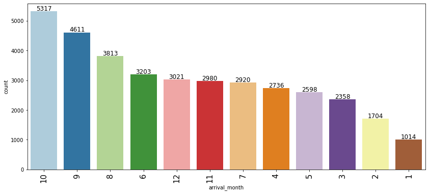

```python
labeled_barplot(data, "arrival_month")
```

### Some transformations to understand better the info

```python
data["arrival_month"] = data["arrival_month"].astype("object")
data.loc[data.arrival_month == 1, "name_month"] = "Jan"
data.loc[data.arrival_month == 2, "name_month"] = "Feb"
data.loc[data.arrival_month == 3, "name_month"] = "Mar"
data.loc[data.arrival_month == 4, "name_month"] = "Apr"
data.loc[data.arrival_month == 5, "name_month"] = "May"
data.loc[data.arrival_month == 6, "name_month"] = "Jun"
data.loc[data.arrival_month == 7, "name_month"] = "Jul"
data.loc[data.arrival_month == 8, "name_month"] = "Aug"
data.loc[data.arrival_month == 9, "name_month"] = "Sep"
data.loc[data.arrival_month == 10, "name_month"] = "Oct"
data.loc[data.arrival_month == 11, "name_month"] = "Nov"
data.loc[data.arrival_month == 12, "name_month"] = "Dec"
data["name_month"] = data["name_month"].astype("category")
```

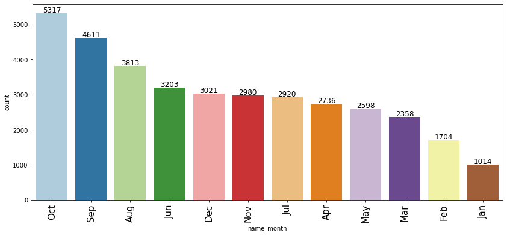

```python
labeled_barplot(data, "name_month")
```

**Jonathan's Note:** The busiest months (Top 3) are Oct, Sep and Aug

## 2. Which market segment do most of the guests come from?

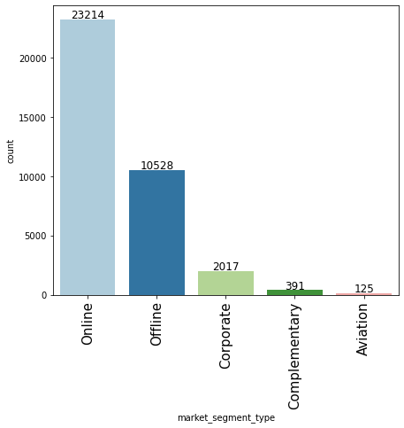

```python
labeled_barplot(data, "market_segment_type")
```

**Jonathan's Note:** The majority of guests comes from Online Market segment

## 3. Hotel rates are dynamic and change according to demand and customer demographics. What are the differences in room prices in different market segments?

```python
data.groupby(["market_segment_type"])["avg_price_per_room"].mean()
```

```
market_segment_type
Aviation         100.704000
Complementary      3.141765
Corporate         82.911740
Offline           91.632679
Online           112.256855
Name: avg_price_per_room, dtype: float64
```

**Jonathan's Note:**

## 4. What percentage of bookings are canceled?

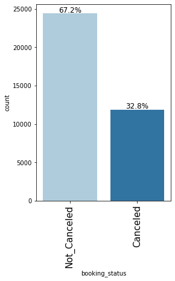

```python
labeled_barplot(data, "booking_status", perc=True)
```

**Jonathan's Note:**

- The percentage of Canceled bookings is 32.8%

## 5. Repeating guests are the guests who stay in the hotel often and are important to brand equity. What percentage of repeating guests cancel?

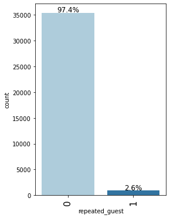

```python
labeled_barplot(data, "repeated_guest", perc=True)
```

**Jonathan's Note:**

- The percentage of repeating guests is 2.6%
- The percentage is very low, could this means that the "customer experience" is not good

## 6. Many guests have special requirements when booking a hotel room. Do these requirements affect booking cancellation?

```
booking_status          Canceled  Not_Canceled    All
no_of_special_requests
All                        11885         24390  36275
0                           8545         11232  19777
1                           2703          8670  11373
2                            637          3727   4364
3                              0           675    675
4                              0            78     78
5                              0             8      8
------------------------------------------------------------------------------------------------------------------------
```

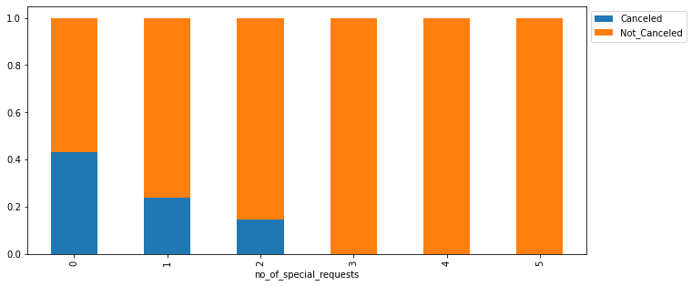

```python
stacked_barplot(data, "no_of_special_requests", "booking_status")
```

**Jonathan's Note:**

## EDA - Univariate

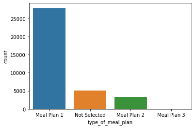

```python
sns.countplot(data=data, x="type_of_meal_plan")
```

**Jonathan's Note:**

- The Meal Plan 1 is the preferred by guests

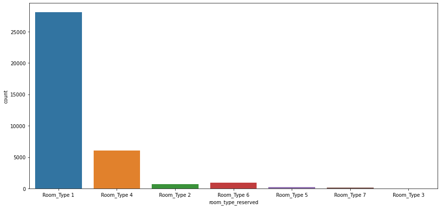

```python
plt.figure(figsize=(15, 7))
sns.countplot(data=data, x="room_type_reserved")
plt.show()
```

**Jonathan's Note:**

- Room Type is the preferred by guests

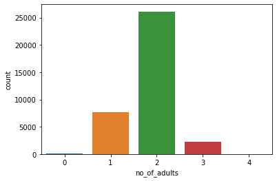

```python
sns.countplot(data=data, x="no_of_adults")
```

**Jonathan's Note:**

- The majority of reservations are done by couples

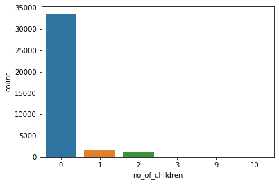

```python
sns.countplot(data=data, x="no_of_children")
```

**Jonathan's Note:**

- The majority of reservations doesn't have children involved

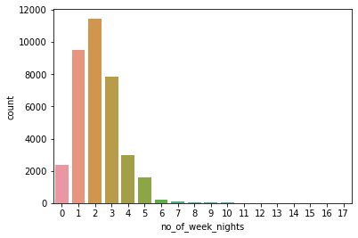

```python
sns.countplot(data=data, x="no_of_week_nights")
```

**Jonathan's Note:**

- The preference number of nights week are between 1 and 3

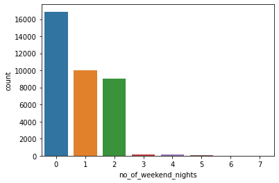

```python
sns.countplot(data=data, x="no_of_weekend_nights")
```

**Jonathan's Note:**

- Regarding the info we could indicate that rooms are often reserved for night week
- On weekends is less busy

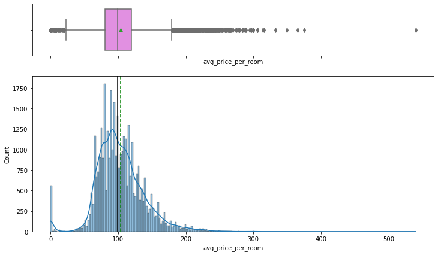

```python
histogram_boxplot(data, "avg_price_per_room", kde=True)
```

**Jonathan's Note:**

## EDA - Bivariate

```
booking_status  Canceled  Not_Canceled    All
name_month
All                11885         24390  36275
Oct                 1880          3437   5317
Sep                 1538          3073   4611
Aug                 1488          2325   3813
Jul                 1314          1606   2920
Jun                 1291          1912   3203
Apr                  995          1741   2736
May                  948          1650   2598
Nov                  875          2105   2980
Mar                  700          1658   2358
Feb                  430          1274   1704
Dec                  402          2619   3021
Jan                   24           990   1014
------------------------------------------------------------------------------------------------------------------------
```

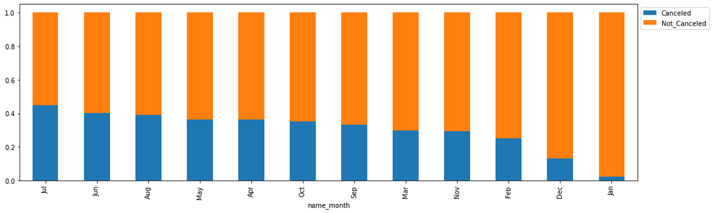

```python
stacked_barplot(data, "name_month", "booking_status")
```

**Jonathan's Note:**

- Month with more cancellations is July
- Month with less cancellations is January

```
repeated_guest      0    1    All
name_month
All             35345  930  36275
Oct              5174  143   5317
Dec              2888  133   3021
Nov              2870  110   2980
Sep              4503  108   4611
Mar              2283   75   2358
Jan               940   74   1014
May              2535   63   2598
Feb              1645   59   1704
Jun              3148   55   3203
Apr              2686   50   2736
Jul              2880   40   2920
Aug              3793   20   3813
------------------------------------------------------------------------------------------------------------------------
```

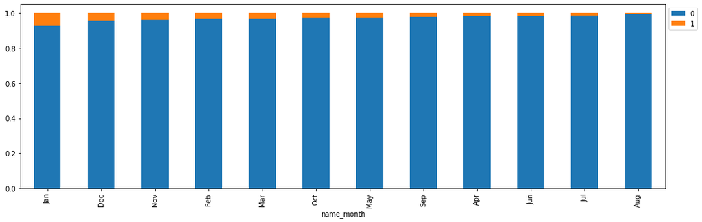

```python
stacked_barplot(data, "name_month", "repeated_guest")
```

**Jonathan's Note:**

```
booking_status      Canceled  Not_Canceled    All
room_type_reserved
All                    11885         24390  36275
Room_Type 1             9072         19058  28130
Room_Type 4             2069          3988   6057
Room_Type 6              406           560    966
Room_Type 2              228           464    692
Room_Type 5               72           193    265
Room_Type 7               36           122    158
Room_Type 3                2             5      7
------------------------------------------------------------------------------------------------------------------------
```

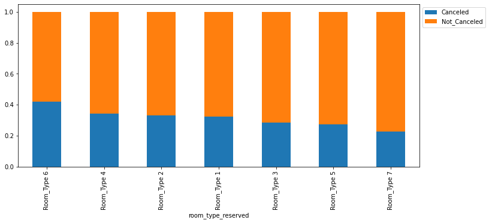

```python
stacked_barplot(data, "room_type_reserved", "booking_status")
```

**Jonathan's Note:**

- The Room Type 6 is the kind of room with more cancellation

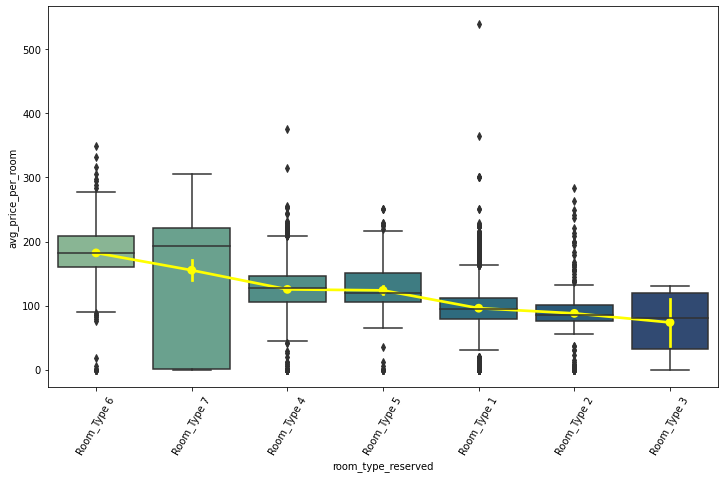

```python
numVsCatPlot(data, "avg_price_per_room", "room_type_reserved")
```

**Jonathan's Note:**

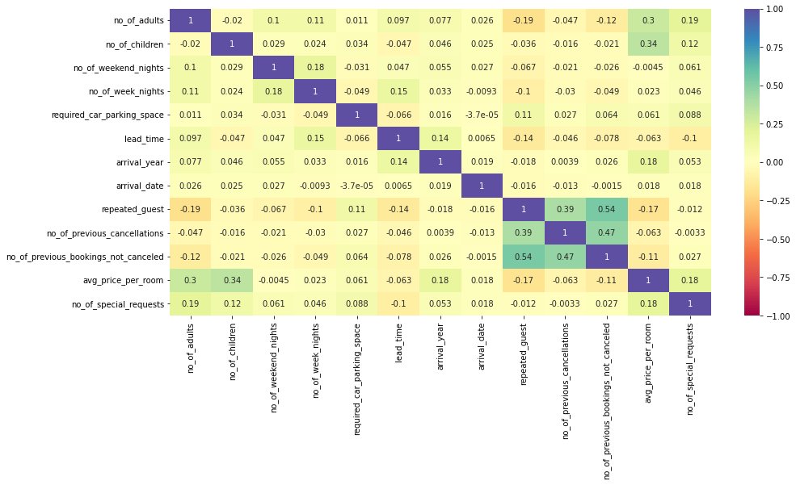

```python
plt.figure(figsize=(15, 7))
sns.heatmap(data.corr(), annot=True, vmin=-1, vmax=1, cmap="Spectral")
plt.show()
```

**Jonathan's Note:**

- The highest correlation is 0.54 between repeated_guest and number of previous booking not cancelled
- The average price for room seems doesn't have a high correlation with other features

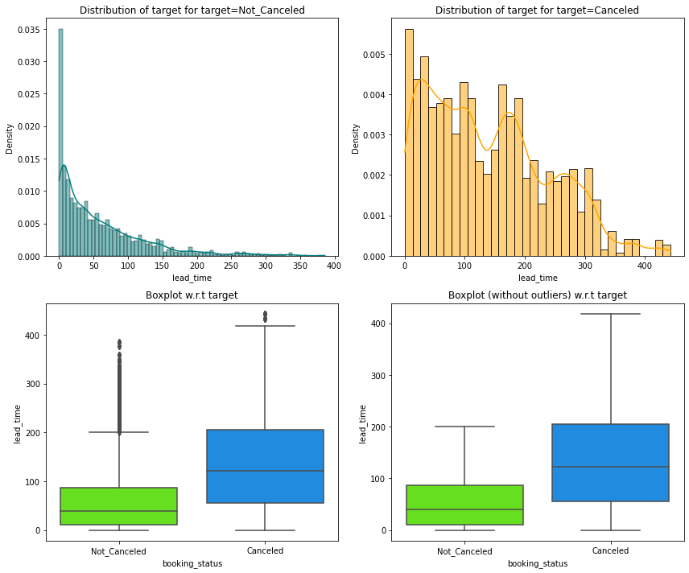

```python
plt.figure(figsize=(20, 10))
distribution_plot_wrt_target(data, "lead_time", "booking_status")
```

**Jonathan's Note:**

- Most of cancellations occurs at high lead time

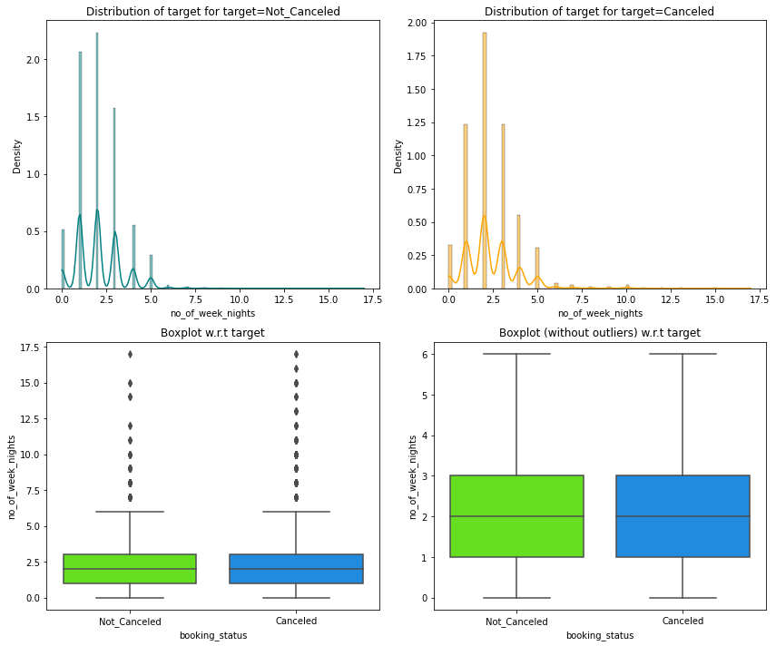

```python
distribution_plot_wrt_target(data, "no_of_week_nights", "booking_status")
```

**Jonathan's Note:**

- There number of nights reserved on week doesn't impact on cancellation

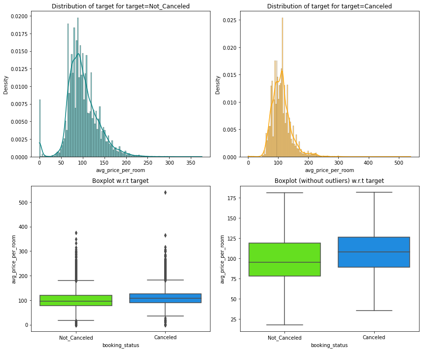

```python
distribution_plot_wrt_target(data, "avg_price_per_room", "booking_status")
```

**Jonathan's Note:**

- Accordingly with the graph the most cancellations occurs meanwhile the avg_price be higher but the difference is really quite low

## Data Preprocessing

- Missing value treatment (if needed)
- Feature engineering (if needed)
- Outlier detection and treatment (if needed)
- Preparing data for modeling
- Any other preprocessing steps (if needed)

## Missing value treatment

```python
# checking for null values
data.isnull().sum()
```

```
Booking_ID                              0
no_of_adults                            0
no_of_children                          0
no_of_weekend_nights                    0
no_of_week_nights                       0
type_of_meal_plan                       0
required_car_parking_space              0
room_type_reserved                      0
lead_time                               0
arrival_year                            0
arrival_month                           0
arrival_date                            0
market_segment_type                     0
repeated_guest                          0
no_of_previous_cancellations            0
no_of_previous_bookings_not_canceled    0
avg_price_per_room                      0
no_of_special_requests                  0
booking_status                          0
name_month                              0
dtype: int64
```

**Jonathan's Note:**

- There is not missing value

## Feature engineering

**Jonathan's Note:** Let's drop and clean a little the dataset from those features that will not needed on the next steps

```python
# First a copy of original dataset
data2 = data.copy()
```

**Jonathan's Note:** Booking_ID is not relevant for modeling and arrival_month was transformed from number to a descriptive name

```python
data2.drop("Booking_ID", axis=1, inplace=True)
data2.drop("arrival_month", axis=1, inplace=True)
```

```python
data2.info()
```

```
<class 'pandas.core.frame.DataFrame'>
RangeIndex: 36275 entries, 0 to 36274
Data columns (total 18 columns):
 #   Column                                Non-Null Count  Dtype
---  ------                                --------------  -----
 0   no_of_adults                          36275 non-null  int64
 1   no_of_children                        36275 non-null  int64
 2   no_of_weekend_nights                  36275 non-null  int64
 3   no_of_week_nights                     36275 non-null  int64
 4   type_of_meal_plan                     36275 non-null  object
 5   required_car_parking_space            36275 non-null  int64
 6   room_type_reserved                    36275 non-null  object
 7   lead_time                             36275 non-null  int64
 8   arrival_year                          36275 non-null  int64
 9   arrival_date                          36275 non-null  int64
 10  market_segment_type                   36275 non-null  object
 11  repeated_guest                        36275 non-null  int64
 12  no_of_previous_cancellations          36275 non-null  int64
 13  no_of_previous_bookings_not_canceled  36275 non-null  int64
 14  avg_price_per_room                    36275 non-null  float64
 15  no_of_special_requests                36275 non-null  int64
 16  booking_status                        36275 non-null  object
 17  name_month                            36275 non-null  category
dtypes: category(1), float64(1), int64(12), object(4)
memory usage: 4.7+ MB
```

## Outlier detection and treatment

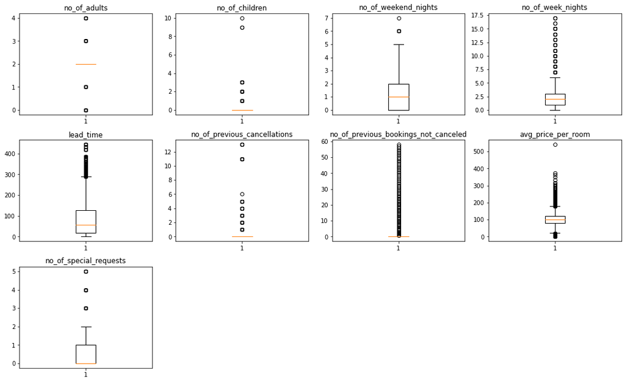

```python
# outlier detection using boxplot
# selecting the numerical columns of data and adding their names in a list
numeric_columns = [
    "no_of_adults",
    "no_of_children",
    "no_of_weekend_nights",
    "no_of_week_nights",
    "lead_time",
    "no_of_previous_cancellations",
    "no_of_previous_bookings_not_canceled",
    "avg_price_per_room",
    "no_of_special_requests",
]
plt.figure(figsize=(15, 12))

for i, variable in enumerate(numeric_columns):
    plt.subplot(4, 4, i + 1)
    plt.boxplot(data[variable], whis=1.5)
    plt.tight_layout()
    plt.title(variable)

plt.show()
```

```python
# to find the 25th percentile and 75th percentile for the numerical columns.
Q1 = data2[numeric_columns].quantile(0.25)
Q3 = data2[numeric_columns].quantile(0.75)

IQR = Q3 - Q1  # Inter Quantile Range (75th percentile - 25th percentile)

lower_whisker = (
    Q1 - 1.5 * IQR
)  # Finding lower and upper bounds for all values. All values outside these bounds are outliers
upper_whisker = Q3 + 1.5 * IQR
```

```python
# Percentage of outliers in each column
(
    (data2[numeric_columns] < lower_whisker) | (data2[numeric_columns] > upper_whisker)
).sum() / data2.shape[0] * 100
```

```
no_of_adults                            28.027567
no_of_children                           7.437629
no_of_weekend_nights                     0.057891
no_of_week_nights                        0.893177
lead_time                                3.669194
no_of_previous_cancellations             0.931771
no_of_previous_bookings_not_canceled     2.238456
avg_price_per_room                       4.675396
no_of_special_requests                   2.097864
dtype: float64
```

### Treating outliers

We will cap/clip the minimum and maximum value of these columns to the lower and upper whisker value of the boxplot found using Q1 - 1.5*IQR and Q3 + 1.5*IQR, respectively.

Note: Generally, a value of 1.5 * IQR is taken to cap the values of outliers to upper and lower whiskers but any number (example 0.5, 2, 3, etc) other than 1.5 can be chosen. The value depends upon the business problem statement.

Creating a function to floor and cap/clip outliers in a column

```python
def treat_outliers(df, col):
    """
    treats outliers in a variable
    col: str, name of the numerical variable
    df: dataframe
    col: name of the column
    """
    Q1 = df[col].quantile(0.25)  # 25th quantile
    Q3 = df[col].quantile(0.75)  # 75th quantile
    IQR = Q3 - Q1  # Inter Quantile Range (75th perentile - 25th percentile)
    lower_whisker = Q1 - 1.5 * IQR
    upper_whisker = Q3 + 1.5 * IQR

    # all the values smaller than lower_whisker will be assigned the value of lower_whisker
    # all the values greater than upper_whisker will be assigned the value of upper_whisker
    # the assignment will be done by using the clip function of NumPy
    df[col] = np.clip(df[col], lower_whisker, upper_whisker)

    return df
```

**Treating outliers in all numerical columns**

```python
data2 = treat_outliers(data2, "no_of_weekend_nights")
data2 = treat_outliers(data2, "no_of_week_nights")
data2 = treat_outliers(data2, "no_of_previous_cancellations")
data2 = treat_outliers(data2, "no_of_previous_bookings_not_canceled")
```

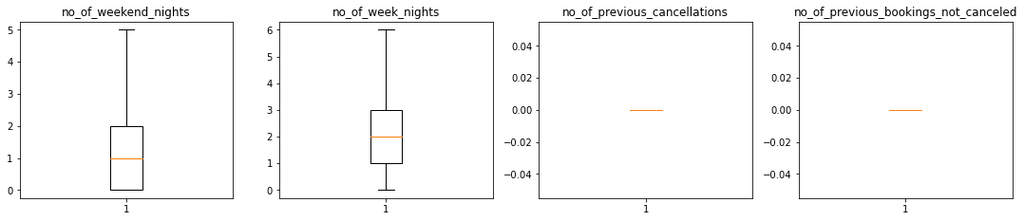

```python
# outlier detection using boxplot
# selecting the numerical columns of data and adding their names in a list
numeric_columns = [
    "no_of_weekend_nights",
    "no_of_week_nights",
    "no_of_previous_cancellations",
    "no_of_previous_bookings_not_canceled",
]
plt.figure(figsize=(15, 12))

for i, variable in enumerate(numeric_columns):
    plt.subplot(4, 4, i + 1)
    plt.boxplot(data2[variable], whis=1.5)
    plt.tight_layout()
    plt.title(variable)

plt.show()
```

**Jonathan's Note:** The outliers has been treated on features selected

### Data Preparation for Modeling

```python
data2["booking_status"] = data2["booking_status"].apply(lambda x: 0 if x == "Canceled" else 1)
```

**Jonathan's Note:** the booking status has been changed in order to have a binaries values 0 for "Cancelled" and 1 for "Not_Cancelled"

```python
for col in [
    "type_of_meal_plan",
    "room_type_reserved",
    "market_segment_type",
    "booking_status",
]:
    data2[col] = data2[col].astype("category")
```

```python
data2.info()
```

```
<class 'pandas.core.frame.DataFrame'>
RangeIndex: 36275 entries, 0 to 36274
Data columns (total 18 columns):
 #   Column                                Non-Null Count  Dtype
---  ------                                --------------  -----
 0   no_of_adults                          36275 non-null  int64
 1   no_of_children                        36275 non-null  int64
 2   no_of_weekend_nights                  36275 non-null  float64
 3   no_of_week_nights                     36275 non-null  float64
 4   type_of_meal_plan                     36275 non-null  category
 5   required_car_parking_space            36275 non-null  int64
 6   room_type_reserved                    36275 non-null  category
 7   lead_time                             36275 non-null  int64
 8   arrival_year                          36275 non-null  int64
 9   arrival_date                          36275 non-null  int64
 10  market_segment_type                   36275 non-null  category
 11  repeated_guest                        36275 non-null  int64
 12  no_of_previous_cancellations          36275 non-null  float64
 13  no_of_previous_bookings_not_canceled  36275 non-null  float64
 14  avg_price_per_room                    36275 non-null  float64
 15  no_of_special_requests                36275 non-null  int64
 16  booking_status                        36275 non-null  category
 17  name_month                            36275 non-null  category
dtypes: category(5), float64(5), int64(8)
memory usage: 3.8 MB
```

```python
X = data2.drop(["booking_status"], axis=1)
Y = data2["booking_status"]
# adding a constant to the independent variables
X = sm.add_constant(X)
# creating dummy variables
X = pd.get_dummies(X, drop_first=True)

# splitting data in train and test sets
X_train, X_test, y_train, y_test = train_test_split(
    X, Y, test_size=0.30, random_state=1
)
```

### Multicollinearity Check

```python
vif_series = pd.Series(
    [variance_inflation_factor(X_train.values, i) for i in range(X_train.shape[1])],
    index=X_train.columns,
    dtype=float,
)
print("Series before feature selection: \n\n{}\n".format(vif_series))
```

```
Series before feature selection:

const                                   4.312468e+07
no_of_adults                            1.387185e+00
no_of_children                          2.007215e+00
no_of_weekend_nights                    1.062599e+00
no_of_week_nights                       1.099920e+00
required_car_parking_space              1.044540e+00
lead_time                               1.548995e+00
arrival_year                            1.563790e+00
arrival_date                            1.014018e+00
repeated_guest                          1.333998e+00
no_of_previous_cancellations                     NaN
no_of_previous_bookings_not_canceled             NaN
avg_price_per_room                      2.535676e+00
no_of_special_requests                  1.249377e+00
type_of_meal_plan_Meal Plan 2           1.293725e+00
type_of_meal_plan_Meal Plan 3           1.025350e+00
type_of_meal_plan_Not Selected          1.283196e+00
room_type_reserved_Room_Type 2          1.103160e+00
room_type_reserved_Room_Type 3          1.003718e+00
room_type_reserved_Room_Type 4          1.369603e+00
room_type_reserved_Room_Type 5          1.028789e+00
room_type_reserved_Room_Type 6          2.001937e+00
room_type_reserved_Room_Type 7          1.119706e+00
market_segment_type_Complementary       4.516367e+00
market_segment_type_Corporate           1.694572e+01
market_segment_type_Offline             6.425690e+01
market_segment_type_Online              7.137807e+01
name_month_Aug                          2.303885e+00
name_month_Dec                          2.025567e+00
name_month_Feb                          1.598906e+00
name_month_Jan                          1.381255e+00
name_month_Jul                          1.988137e+00
name_month_Jun                          2.042844e+00
name_month_Mar                          1.762898e+00
name_month_May                          1.856416e+00
name_month_Nov                          1.995060e+00
name_month_Oct                          2.808180e+00
name_month_Sep                          2.689216e+00
dtype: float64
```

```python
X_train1 = X_train.drop("no_of_previous_cancellations", axis=1)
vif_series2 = pd.Series(
    [variance_inflation_factor(X_train1.values, i) for i in range(X_train1.shape[1])],
    index=X_train1.columns,
).sort_values(ascending=False)
print("Series before feature selection: \n\n{}\n".format(vif_series2))
```

```
Series before feature selection:

const                                   4.312468e+07
market_segment_type_Online              7.137807e+01
market_segment_type_Offline             6.425690e+01
market_segment_type_Corporate           1.694572e+01
market_segment_type_Complementary       4.516367e+00
name_month_Oct                          2.808180e+00
name_month_Sep                          2.689216e+00
avg_price_per_room                      2.535676e+00
name_month_Aug                          2.303885e+00
name_month_Jun                          2.042844e+00
name_month_Dec                          2.025567e+00
no_of_children                          2.007215e+00
room_type_reserved_Room_Type 6          2.001937e+00
name_month_Nov                          1.995060e+00
name_month_Jul                          1.988137e+00
name_month_May                          1.856416e+00
name_month_Mar                          1.762898e+00
name_month_Feb                          1.598906e+00
arrival_year                            1.563790e+00
lead_time                               1.548995e+00
no_of_adults                            1.387185e+00
name_month_Jan                          1.381255e+00
room_type_reserved_Room_Type 4          1.369603e+00
repeated_guest                          1.333998e+00
type_of_meal_plan_Meal Plan 2           1.293725e+00
type_of_meal_plan_Not Selected          1.283196e+00
no_of_special_requests                  1.249377e+00
room_type_reserved_Room_Type 7          1.119706e+00
room_type_reserved_Room_Type 2          1.103160e+00
no_of_week_nights                       1.099920e+00
no_of_weekend_nights                    1.062599e+00
required_car_parking_space              1.044540e+00
room_type_reserved_Room_Type 5          1.028789e+00
type_of_meal_plan_Meal Plan 3           1.025350e+00
arrival_date                            1.014018e+00
room_type_reserved_Room_Type 3          1.003718e+00
no_of_previous_bookings_not_canceled             NaN
dtype: float64
```

```python
X_train2 = X_train1.drop("no_of_previous_bookings_not_canceled", axis=1)
vif_series3 = pd.Series(
    [variance_inflation_factor(X_train2.values, i) for i in range(X_train2.shape[1])],
    index=X_train2.columns,
).sort_values(ascending=False)
print("Series before feature selection: \n\n{}\n".format(vif_series3))
```

```
Series before feature selection:

const                                4.312468e+07
market_segment_type_Online           7.137807e+01
market_segment_type_Offline          6.425690e+01
market_segment_type_Corporate        1.694572e+01
market_segment_type_Complementary    4.516367e+00
name_month_Oct                       2.808180e+00
name_month_Sep                       2.689216e+00
avg_price_per_room                   2.535676e+00
name_month_Aug                       2.303885e+00
name_month_Jun                       2.042844e+00
name_month_Dec                       2.025567e+00
no_of_children                       2.007215e+00
room_type_reserved_Room_Type 6       2.001937e+00
name_month_Nov                       1.995060e+00
name_month_Jul                       1.988137e+00
name_month_May                       1.856416e+00
name_month_Mar                       1.762898e+00
name_month_Feb                       1.598906e+00
arrival_year                         1.563790e+00
lead_time                            1.548995e+00
no_of_adults                         1.387185e+00
name_month_Jan                       1.381255e+00
room_type_reserved_Room_Type 4       1.369603e+00
repeated_guest                       1.333998e+00
type_of_meal_plan_Meal Plan 2        1.293725e+00
type_of_meal_plan_Not Selected       1.283196e+00
no_of_special_requests               1.249377e+00
room_type_reserved_Room_Type 7       1.119706e+00
room_type_reserved_Room_Type 2       1.103160e+00
no_of_week_nights                    1.099920e+00
no_of_weekend_nights                 1.062599e+00
required_car_parking_space           1.044540e+00
room_type_reserved_Room_Type 5       1.028789e+00
type_of_meal_plan_Meal Plan 3        1.025350e+00
arrival_date                         1.014018e+00
room_type_reserved_Room_Type 3       1.003718e+00
dtype: float64
```

```python
X_train3 = X_train2.drop("market_segment_type_Online", axis=1)
vif_series4 = pd.Series(
    [variance_inflation_factor(X_train3.values, i) for i in range(X_train3.shape[1])],
    index=X_train3.columns,
).sort_values(ascending=False)
print("Series before feature selection: \n\n{}\n".format(vif_series4))
```

```
Series before feature selection:

const                                4.301095e+07
name_month_Oct                       2.807733e+00
name_month_Sep                       2.688840e+00
avg_price_per_room                   2.532023e+00
name_month_Aug                       2.303865e+00
name_month_Jun                       2.042642e+00
name_month_Dec                       2.025207e+00
no_of_children                       2.006671e+00
room_type_reserved_Room_Type 6       2.001363e+00
name_month_Nov                       1.995055e+00
name_month_Jul                       1.988082e+00
name_month_May                       1.856026e+00
name_month_Mar                       1.761785e+00
market_segment_type_Offline          1.639368e+00
name_month_Feb                       1.597296e+00
arrival_year                         1.560067e+00
lead_time                            1.542563e+00
market_segment_type_Corporate        1.520390e+00
name_month_Jan                       1.379872e+00
market_segment_type_Complementary    1.377666e+00
no_of_adults                         1.372043e+00
room_type_reserved_Room_Type 4       1.363784e+00
repeated_guest                       1.332294e+00
type_of_meal_plan_Meal Plan 2        1.293156e+00
type_of_meal_plan_Not Selected       1.281040e+00
no_of_special_requests               1.244333e+00
room_type_reserved_Room_Type 7       1.119525e+00
room_type_reserved_Room_Type 2       1.103030e+00
no_of_week_nights                    1.099740e+00
no_of_weekend_nights                 1.062092e+00
required_car_parking_space           1.044328e+00
room_type_reserved_Room_Type 5       1.028788e+00
type_of_meal_plan_Meal Plan 3        1.025350e+00
arrival_date                         1.013981e+00
room_type_reserved_Room_Type 3       1.003718e+00
dtype: float64
```

**Jonathan's Note**: The multicollinearity has been treated

### Fitting Logistic Regression model

```python
# fitting the model on training set
logit = sm.Logit(y_train, X_train3.astype(float))
lg = logit.fit()
```

```python
print(lg.summary())
```

```
                           Logit Regression Results
==============================================================================
Dep. Variable:         booking_status   No. Observations:                25392
Model:                          Logit   Df Residuals:                    25357
Method:                           MLE   Df Model:                           34
Date:                Thu, 22 Sep 2022   Pseudo R-squ.:                  0.3482
Time:                        22:23:05   Log-Likelihood:                -10489.
converged:                      False   LL-Null:                       -16091.
Covariance Type:            nonrobust   LLR p-value:                     0.000
=====================================================================================================
                                        coef    std err          z      P>|z|      [0.025      0.975]
-----------------------------------------------------------------------------------------------------
const                               995.9387    128.677      7.740      0.000     743.737    1248.140
no_of_adults                         -0.1467      0.039     -3.797      0.000      -0.222      -0.071
no_of_children                       -0.2093      0.060     -3.504      0.000      -0.326      -0.092
no_of_weekend_nights                 -0.1253      0.020     -6.223      0.000      -0.165      -0.086
no_of_week_nights                    -0.0230      0.014     -1.655      0.098      -0.050       0.004
required_car_parking_space            1.5842      0.139     11.391      0.000       1.312       1.857
lead_time                            -0.0162      0.000    -55.853      0.000      -0.017      -0.016
arrival_year                         -0.4920      0.064     -7.715      0.000      -0.617      -0.367
arrival_date                         -0.0023      0.002     -1.142      0.254      -0.006       0.002
repeated_guest                        1.9675      0.407      4.832      0.000       1.169       2.766
avg_price_per_room                   -0.0186      0.001    -22.264      0.000      -0.020      -0.017
no_of_special_requests                1.5184      0.031     49.461      0.000       1.458       1.579
type_of_meal_plan_Meal Plan 2        -0.1987      0.069     -2.891      0.004      -0.333      -0.064
type_of_meal_plan_Meal Plan 3       -16.7885   2844.992     -0.006      0.995   -5592.871    5559.294
type_of_meal_plan_Not Selected       -0.2779      0.054     -5.140      0.000      -0.384      -0.172
room_type_reserved_Room_Type 2        0.3358      0.135      2.485      0.013       0.071       0.601
room_type_reserved_Room_Type 3        0.1741      1.308      0.133      0.894      -2.389       2.738
room_type_reserved_Room_Type 4        0.2659      0.054      4.955      0.000       0.161       0.371
room_type_reserved_Room_Type 5        0.7636      0.212      3.595      0.000       0.347       1.180
room_type_reserved_Room_Type 6        0.9553      0.152      6.294      0.000       0.658       1.253
room_type_reserved_Room_Type 7        1.3775      0.299      4.607      0.000       0.791       1.963
market_segment_type_Complementary    27.7482   3161.547      0.009      0.993   -6168.771    6224.267
market_segment_type_Corporate         0.8098      0.105      7.684      0.000       0.603       1.016
market_segment_type_Offline           1.8397      0.054     34.298      0.000       1.735       1.945
name_month_Aug                        0.2530      0.079      3.193      0.001       0.098       0.408
name_month_Dec                        1.5605      0.102     15.233      0.000       1.360       1.761
name_month_Feb                       -0.4580      0.095     -4.820      0.000      -0.644      -0.272
name_month_Jan                        2.3780      0.263      9.037      0.000       1.862       2.894
name_month_Jul                        0.2626      0.081      3.224      0.001       0.103       0.422
name_month_Jun                        0.1671      0.079      2.114      0.034       0.012       0.322
name_month_Mar                       -0.2581      0.084     -3.086      0.002      -0.422      -0.094
name_month_May                        0.3935      0.083      4.764      0.000       0.232       0.555
name_month_Nov                       -0.3219      0.086     -3.763      0.000      -0.490      -0.154
name_month_Oct                        0.0596      0.077      0.772      0.440      -0.092       0.211
name_month_Sep                        0.3143      0.081      3.891      0.000       0.156       0.473
=====================================================================================================
```

**Jonathan's Observations**

## Model performance evaluation

**Model can make wrong predictions as**:

1. Predicting a person will cancel a booking, when a person will not cancel the booking (False Negatives).
2. Predicting a person will not cancel a booking, when a person will cancel the booking (False Positives)

**Which case is more important?**

- Both the cases are important as:
1. False negatives could lead a loss of revenue of chain hotel
2. False positives will result in last minute cancellations and maybe the chain will have to launch last minute deals with cheaper prices

As is shown two cases identified could address to a loss revenue

**First, let's create functions to calculate different metrics and confusion matrix so that we don't have to use the same code repeatedly for each model.**

- The model_performance_classification_statsmodels function will be used to check the model performance of models.
- The confusion_matrix_statsmodels function will be used to plot confusion matrix.

```python
# defining a function to compute different metrics to check performance of a classification model built using statsmodels
def model_performance_classification_statsmodels(
    model, predictors, target, threshold=0.5
):
    """
    Function to compute different metrics to check classification model performance

    model: classifier
    predictors: independent variables
    target: dependent variable
    threshold: threshold for classifying the observation as class 1
    """

    # checking which probabilities are greater than threshold
    pred_temp = model.predict(predictors) > threshold
    # rounding off the above values to get classes
    pred = np.round(pred_temp)

    acc = accuracy_score(target, pred)  # to compute Accuracy
    recall = recall_score(target, pred)  # to compute Recall
    precision = precision_score(target, pred)  # to compute Precision
    f1 = f1_score(target, pred)  # to compute F1-score

    # creating a dataframe of metrics
    df_perf = pd.DataFrame(
        {"Accuracy": acc, "Recall": recall, "Precision": precision, "F1": f1,},
        index=[0],
    )

    return df_perf
```

```python
# defining a function to plot the confusion_matrix of a classification model


def confusion_matrix_statsmodels(model, predictors, target, threshold=0.5):
    """
    To plot the confusion_matrix with percentages

    model: classifier
    predictors: independent variables
    target: dependent variable
    threshold: threshold for classifying the observation as class 1
    """
    y_pred = model.predict(predictors) > threshold
    cm = confusion_matrix(target, y_pred)
    labels = np.asarray(
        [
            ["{0:0.0f}".format(item) + "\n{0:.2%}".format(item / cm.flatten().sum())]
            for item in cm.flatten()
        ]
    ).reshape(2, 2)

    plt.figure(figsize=(6, 4))
    sns.heatmap(cm, annot=labels, fmt="")
    plt.ylabel("True label")
    plt.xlabel("Predicted label")
```

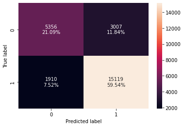

```python
confusion_matrix_statsmodels(lg, X_train3, y_train)
```

```python
print("Training performance:")
model_performance_classification_statsmodels(lg, X_train3, y_train)
```

```
Training performance:
```

|  | Accuracy | Recall | Precision | F1 |
| --- | --- | --- | --- | --- |
| 0 | 0.806356 | 0.887838 | 0.834106 | 0.860134 |

**Observations**

- The f1_score of the model is ~0.86 and we will try to maximize it further
- The multicollinearity was treated in a previous step so the model is not affected by this
- We will have to remove the features with p-values greather than 0,05

### Removing high p-value variables

```python
#initial list of columns
cols = X_train3.columns.tolist()

# setting an initial max p-value
max_p_value = 1

while len(cols) > 0:
    # defining the train set
    X_train_aux = X_train3[cols]

    # fitting the model
    model = sm.Logit(y_train, X_train_aux).fit(disp=False)

    # getting the p-values and the maximum p-value
    p_values = model.pvalues
    max_p_value = max(p_values)

    # name of the variable with maximum p-value
    feature_with_p_max = p_values.idxmax()

    if max_p_value > 0.05:
        cols.remove(feature_with_p_max)
    else:
        break

selected_features = cols
print(selected_features)
```

[output not shown]

```python
X_train4 = X_train3[selected_features]
```

```python
logit2 = sm.Logit(y_train, X_train4.astype(float))
lg2 = logit2.fit(disp=False)

print(lg2.summary())
```

```
                           Logit Regression Results
==============================================================================
Dep. Variable:         booking_status   No. Observations:                25392
Model:                          Logit   Df Residuals:                    25363
Method:                           MLE   Df Model:                           28
Date:                Thu, 22 Sep 2022   Pseudo R-squ.:                  0.3472
Time:                        22:23:06   Log-Likelihood:                -10504.
converged:                       True   LL-Null:                       -16091.
Covariance Type:            nonrobust   LLR p-value:                     0.000
==================================================================================================
                                     coef    std err          z      P>|z|      [0.025      0.975]
--------------------------------------------------------------------------------------------------
const                           1016.3680    122.507      8.296      0.000     776.259    1256.477
no_of_adults                      -0.1534      0.038     -3.989      0.000      -0.229      -0.078
no_of_children                    -0.2105      0.060     -3.526      0.000      -0.328      -0.094
no_of_weekend_nights              -0.1309      0.020     -6.550      0.000      -0.170      -0.092
required_car_parking_space         1.5918      0.139     11.441      0.000       1.319       1.865
lead_time                         -0.0162      0.000    -57.564      0.000      -0.017      -0.016
arrival_year                      -0.5022      0.061     -8.269      0.000      -0.621      -0.383
repeated_guest                     1.9984      0.407      4.916      0.000       1.202       2.795
avg_price_per_room                -0.0189      0.001    -23.437      0.000      -0.021      -0.017
no_of_special_requests             1.5176      0.031     49.741      0.000       1.458       1.577
type_of_meal_plan_Meal Plan 2     -0.1868      0.068     -2.734      0.006      -0.321      -0.053
type_of_meal_plan_Not Selected    -0.2789      0.054     -5.208      0.000      -0.384      -0.174
room_type_reserved_Room_Type 2     0.3256      0.135      2.411      0.016       0.061       0.590
room_type_reserved_Room_Type 4     0.2631      0.053      4.927      0.000       0.158       0.368
room_type_reserved_Room_Type 5     0.7730      0.212      3.651      0.000       0.358       1.188
room_type_reserved_Room_Type 6     0.9720      0.151      6.422      0.000       0.675       1.269
room_type_reserved_Room_Type 7     1.4023      0.298      4.700      0.000       0.818       1.987
market_segment_type_Corporate      0.8026      0.105      7.651      0.000       0.597       1.008
market_segment_type_Offline        1.8351      0.053     34.376      0.000       1.730       1.940
name_month_Aug                     0.2155      0.064      3.355      0.001       0.090       0.341
name_month_Dec                     1.5144      0.092     16.390      0.000       1.333       1.695
name_month_Feb                    -0.5059      0.088     -5.764      0.000      -0.678      -0.334
name_month_Jan                     2.3415      0.261      8.978      0.000       1.830       2.853
name_month_Jul                     0.2232      0.068      3.303      0.001       0.091       0.356
name_month_Jun                     0.1317      0.066      2.004      0.045       0.003       0.261
name_month_Mar                    -0.3077      0.075     -4.121      0.000      -0.454      -0.161
name_month_May                     0.3582      0.070      5.093      0.000       0.220       0.496
name_month_Nov                    -0.3594      0.074     -4.865      0.000      -0.504      -0.215
name_month_Sep                     0.2774      0.063      4.386      0.000       0.153       0.401
==================================================================================================
```

**Now no categorical feature has p-value greater than 0.05, so we'll consider the features in *X_train4* as the final ones and *lg2* as final model.**

**Converting coefficients to odds**

- The coefficients ($\beta$s) of the logistic regression model are in terms of $log(odds)$ and to find the odds, we have to take the exponential of the coefficients
- Therefore, **$odds = exp(\beta)$**
- The percentage change in odds is given as $(exp(\beta) - 1) * 100$

That's not strictly correct. The odds depend on x as well since we have $$Log(odds(x)) = Log \left ( \frac{p(x)}{1 - p(x)} \right ) = intercept + \beta_i x_i$$ Hence $$Odds(x) = exp \left ( intercept + \beta_i x_i\right )$$

Now, if you change $x_i$ by one unit, the odds is multiplied by $e^\beta_i$

$$Odds(x+1) = exp \left ( intercept + \beta_i (x_i + 1)\right ) = exp \left ( intercept + \beta_i x_i\right ) \times exp(\beta_i) = Odds(x) \times exp(\beta_i)$$

So $e^\beta_i$ is the multiplicative change of the odds when $x_i$ changes by one unit. That's the odds ratio !

The relative change is then $$\frac{Odds(x+1) - Odds(x)}{Odds(x)} = e^\beta - 1$$

```python
lg2.params
```

```
const                             1016.368021
no_of_adults                        -0.153434
no_of_children                      -0.210522
no_of_weekend_nights                -0.130893
required_car_parking_space           1.591840
lead_time                           -0.016245
arrival_year                        -0.502164
repeated_guest                       1.998419
avg_price_per_room                  -0.018919
no_of_special_requests               1.517633
type_of_meal_plan_Meal Plan 2       -0.186838
type_of_meal_plan_Not Selected      -0.278929
room_type_reserved_Room_Type 2       0.325561
room_type_reserved_Room_Type 4       0.263111
room_type_reserved_Room_Type 5       0.772988
room_type_reserved_Room_Type 6       0.972008
room_type_reserved_Room_Type 7       1.402339
market_segment_type_Corporate        0.802571
market_segment_type_Offline          1.835126
name_month_Aug                       0.215546
name_month_Dec                       1.514385
name_month_Feb                      -0.505950
name_month_Jan                       2.341504
name_month_Jul                       0.223243
name_month_Jun                       0.131703
name_month_Mar                      -0.307741
name_month_May                       0.358158
name_month_Nov                      -0.359383
name_month_Sep                       0.277355
dtype: float64
```

```python
# converting coefficients to odds
odds = np.exp(lg2.params)

# finding the percentage change
perc_change_odds = (np.exp(lg2.params) - 1) * 100

# removing limit from number of columns to display
pd.set_option("display.max_columns", None)

# adding the odds to a dataframe
pd.DataFrame({"Odds": odds, "Change_odd%": perc_change_odds}, index=X_train4.columns).T
```

|  | const | no_of_adults | no_of_children | no_of_weekend_nights | required_car_parking_space | lead_time | arrival_year | repeated_guest | avg_price_per_room | no_of_special_requests | type_of_meal_plan_Meal Plan 2 | type_of_meal_plan_Not Selected | room_type_reserved_Room_Type 2 | room_type_reserved_Room_Type 4 | room_type_reserved_Room_Type 5 | room_type_reserved_Room_Type 6 | room_type_reserved_Room_Type 7 | market_segment_type_Corporate | market_segment_type_Offline | name_month_Aug | name_month_Dec | name_month_Feb | name_month_Jan | name_month_Jul | name_month_Jun | name_month_Mar | name_month_May | name_month_Nov | name_month_Sep |
| --- | --- | --- | --- | --- | --- | --- | --- | --- | --- | --- | --- | --- | --- | --- | --- | --- | --- | --- | --- | --- | --- | --- | --- | --- | --- | --- | --- | --- | --- |
| Odds | inf | 0.857758 | 0.810162 | 0.877312 | 4.912780 | 0.983886 | 0.605220 | 7.377383 | 0.981259 | 4.561415 | 0.829578 | 0.756594 | 1.384808 | 1.300972 | 2.166229 | 2.643246 | 4.064698 | 2.231270 | 6.265925 | 1.240540 | 4.546623 | 0.602933 | 10.396865 | 1.250125 | 1.140769 | 0.735106 | 1.430692 | 0.698107 | 1.319635 |
| Change_odd% | inf | -14.224242 | -18.983844 | -12.268820 | 391.278039 | -1.611416 | -39.478019 | 637.738337 | -1.874103 | 356.141483 | -17.042206 | -24.340615 | 38.480770 | 30.097173 | 116.622935 | 164.324552 | 306.469804 | 123.126988 | 526.592451 | 24.053964 | 354.662254 | -39.706731 | 939.686481 | 25.012464 | 14.076900 | -26.489423 | 43.069179 | -30.189328 | 31.963492 |

**Coefficient interpretations**